# Logistic Regression

We are ssuming clean data (again) so that we can focus on understanding logistic regression.

What do the columns represent?

```r
?ISLR::Default
head(dat)
```

```
## # A tibble: 6 x 4
##   default student balance income
##   <fct>   <fct>     <dbl>  <dbl>
## 1 No      No         730. 44362.
## 2 No      Yes        817. 12106.
## 3 No      No        1074. 31767.
## 4 No      No         529. 35704.
## 5 No      No         786. 38463.
## 6 No      Yes        920.  7492.
```

Let’s make life easier for ourselves and convert `default` to a 0 or 1 instead of “yes” or “no”

```r
dat = dat %>%
  mutate(default = as.numeric(default) - 1) # why the -1?
head(dat)
```

```
## # A tibble: 6 x 4
##   default student balance income
##     <dbl> <fct>     <dbl>  <dbl>
## 1       0 No         730. 44362.
## 2       0 Yes        817. 12106.
## 3       0 No        1074. 31767.
## 4       0 No         529. 35704.
## 5       0 No         786. 38463.
## 6       0 Yes        920.  7492.
```

## Logistic Regression

Recall that our model for linear regression is: `y = mx + b`

```
y = dependent variable (prediction)
m = slope
x = independent variable (predictor)
b = y-intercept
```

Change to exponential is easy `e` is `exp()` in R. All of the rest of the variables in the equation remain the same.

```
y = exp(mx + b) / (1 + exp(mx + b))
y = dependent variable (prediction)
m = slope
x = independent variable (predictor)
b = y-intercept
```

By looking at the basic arithmetic of the equition, what can we infer about `y`?

Let’s go ahead and start some basic analysis. What does `default` vs `balance` look like as a boxplot and scatter plot?

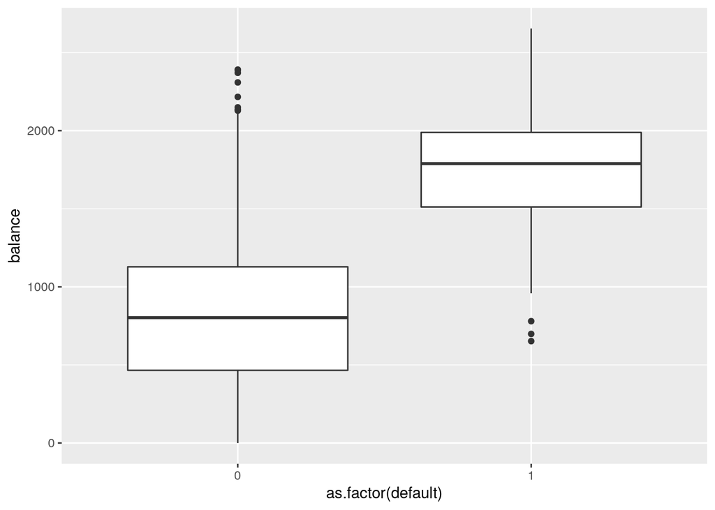

```r
dat %>%
  ggplot(aes(x = as.factor(default), y = balance)) +
  geom_boxplot()
```

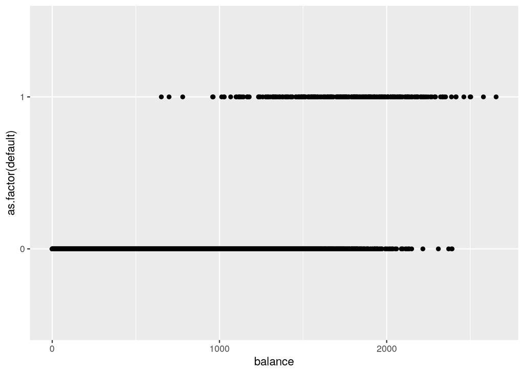

```r
dat %>%
  ggplot(aes(x = balance, y = as.factor(default))) +
  geom_point()
```

Let’s fit a linear model.

```r
# If fitting in R
model_lin = lm(default ~ balance, data = dat)
model_lin
```

```
##
## Call:
## lm(formula = default ~ balance, data = dat)
##
## Coefficients:
## (Intercept)      balance
##  -0.0751920    0.0001299
```

```r
# "By hand"
m = 0.0001299
b = -0.0751920

dat_model_lin = dat %>%
  mutate(default_predicted = (m*balance) + b)
head(dat_model_lin)
```

```
## # A tibble: 6 x 5
##   default student balance income default_predicted
##     <dbl> <fct>     <dbl>  <dbl>             <dbl>
## 1       0 No         730. 44362.           0.0196
## 2       0 Yes        817. 12106.           0.0310
## 3       0 No        1074. 31767.           0.0643
## 4       0 No         529. 35704.          -0.00644
## 5       0 No         786. 38463.           0.0269
## 6       0 Yes        920.  7492.           0.0443
```

```r
## How do you interpret results?
```

What does our new model look like in a plot?

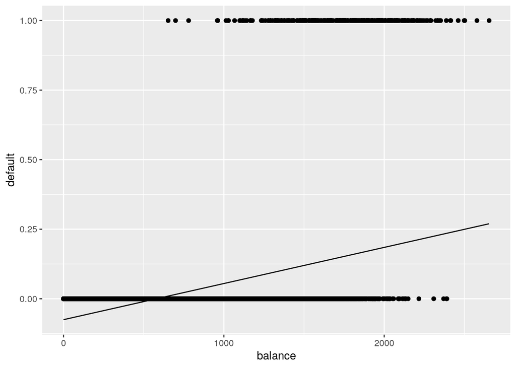

```r
dat_model_lin %>%
  ggplot(aes(x = balance)) +
  geom_point(aes(y = default)) +
  geom_line(aes(y = default_predicted))
```

How do we interpret the previous plot? What does a negative default value mean?

When was `default` predicted as a 0 or 1?

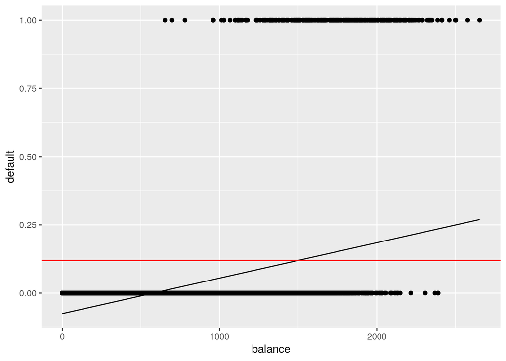

```r
default_threshold = 0.12

dat_model_lin %>%
  ggplot(aes(x = balance)) +
  geom_point(aes(y = default)) +
  geom_line(aes(y = default_predicted)) +
  geom_hline(yintercept = default_threshold, col = 'red')
```

Any data beyond the intersection of the red and black lines will be predicted as a “default”

How do we add the threshold into our model? What do the results look like?

```r
dat_model_lin_preds = dat_model_lin %>%
  mutate(default_predicted_2 = if_else(default_predicted > default_threshold, 1, 0))
dat_model_lin_preds %>%
  select(default, balance, income, default_predicted, default_predicted_2)
```

```
## # A tibble: 10,000 x 5
##    default balance income default_predicted default_predicted_2
##      <dbl>   <dbl>  <dbl>             <dbl>               <dbl>
##  1       0    730. 44362.           0.0196                    0
##  2       0    817. 12106.           0.0310                    0
##  3       0   1074. 31767.           0.0643                    0
##  4       0    529. 35704.          -0.00644                   0
##  5       0    786. 38463.           0.0269                    0
##  6       0    920.  7492.           0.0443                    0
##  7       0    826. 24905.           0.0320                    0
##  8       0    809. 17600.           0.0299                    0
##  9       0   1161. 37469.           0.0756                    0
## 10       0      0  29275.          -0.0752                    0
## # … with 9,990 more rows
```

How accurate is our model? How do we calculate it?

```r
dat_model_lin_preds = dat_model_lin_preds %>%
  mutate(predicted_correct = if_else(default == default_predicted_2, 1, 0))
dat_model_lin_preds %>%
  select(balance, default, default_predicted_2, predicted_correct)
```

```
## # A tibble: 10,000 x 4
##    balance default default_predicted_2 predicted_correct
##      <dbl>   <dbl>               <dbl>             <dbl>
##  1    730.       0                   0                 1
##  2    817.       0                   0                 1
##  3   1074.       0                   0                 1
##  4    529.       0                   0                 1
##  5    786.       0                   0                 1
##  6    920.       0                   0                 1
##  7    826.       0                   0                 1
##  8    809.       0                   0                 1
##  9   1161.       0                   0                 1
## 10      0        0                   0                 1
## # … with 9,990 more rows
```

```r
total_number_of_rows = nrow(dat)

dat_model_lin_preds %>%
  summarize(predicted_correct = sum(predicted_correct)) %>%
  mutate(pct_correct = predicted_correct / total_number_of_rows)
```

```
## # A tibble: 1 x 2
##   predicted_correct pct_correct
##               <dbl>       <dbl>
## 1              9274       0.927
```

Wow, 92.7% accuracy!

However, what did we say about accuracy?

```r
dat %>%
  group_by(default) %>%
  count() %>%
  ungroup() %>%
  mutate(pct_of_data = n / total_number_of_rows)
```

```
## # A tibble: 2 x 3
##   default     n pct_of_data
##     <dbl> <int>       <dbl>
## 1       0  9667      0.967
## 2       1   333      0.0333
```

We would have been right 96.67% of the time had we just said no default the entire time. This is what’s known as the “base rate”

Understand the “base rate fallacy” is a real problem and most people don’t understand it well. Let’s crank up the threshold and see what happens, a normal number to consider is 0.5 — after all, you’re saying you’re predicting something.

```r
default_threshold = 0.5

dat_model_lin %>%
  mutate(default_predicted_2 = if_else(default_predicted > default_threshold, 1, 0)) %>%
  mutate(predicted_correct = if_else(default == default_predicted_2, 1, 0)) %>%
  summarize(predicted_correct = sum(predicted_correct)) %>%
  mutate(pct_correct = predicted_correct / total_number_of_rows)
```

```
## # A tibble: 1 x 2
##   predicted_correct pct_correct
##               <dbl>       <dbl>
## 1              9667       0.967
```

We get the same as the base rate!?!?!? Why is that?

How do you interpret the coefficient of a linear regression?

How do we create a logistic regression?

```r
model_log <- glm(default ~ balance, family = 'binomial', data = dat)
summary(model_log)
```

```
##
## Call:
## glm(formula = default ~ balance, family = "binomial", data = dat)
##
## Deviance Residuals:
##     Min       1Q   Median       3Q      Max
## -2.2697  -0.1465  -0.0589  -0.0221   3.7589
##
## Coefficients:
##               Estimate Std. Error z value Pr(>|z|)
## (Intercept) -1.065e+01  3.612e-01  -29.49   <2e-16 ***
## balance      5.499e-03  2.204e-04   24.95   <2e-16 ***
## ---
## Signif. codes:  0 '***' 0.001 '**' 0.01 '*' 0.05 '.' 0.1 ' ' 1
##
## (Dispersion parameter for binomial family taken to be 1)
##
##     Null deviance: 2920.6  on 9999  degrees of freedom
## Residual deviance: 1596.5  on 9998  degrees of freedom
## AIC: 1600.5
##
## Number of Fisher Scoring iterations: 8
```

Let’s do it “by hand”

```r
m = 0.05
b = -30

# How to add "e"
dat_model_log = dat %>%
  mutate(default = as.integer(default)) %>%
  mutate(logistic_reg = (exp(m*balance + b))/(1 + (exp(m*balance + b))))

head(dat_model_log)
```

```
## # A tibble: 6 x 5
##   default student balance income logistic_reg
##     <int> <fct>     <dbl>  <dbl>        <dbl>
## 1       0 No         730. 44362.       0.998
## 2       0 Yes        817. 12106.       1.000
## 3       0 No        1074. 31767.       1.000
## 4       0 No         529. 35704.       0.0283
## 5       0 No         786. 38463.       1.000
## 6       0 Yes        920.  7492.       1.000
```

How can we visualize the results?

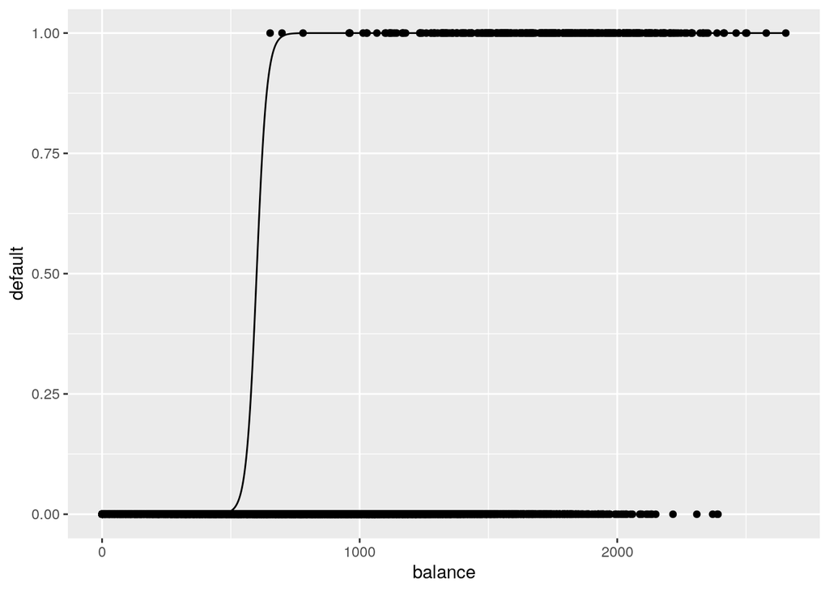

```r
dat_model_log %>%
  ggplot(aes(x = balance)) +
  geom_point(aes(y = default)) +
  geom_line(aes(y = logistic_reg))
```

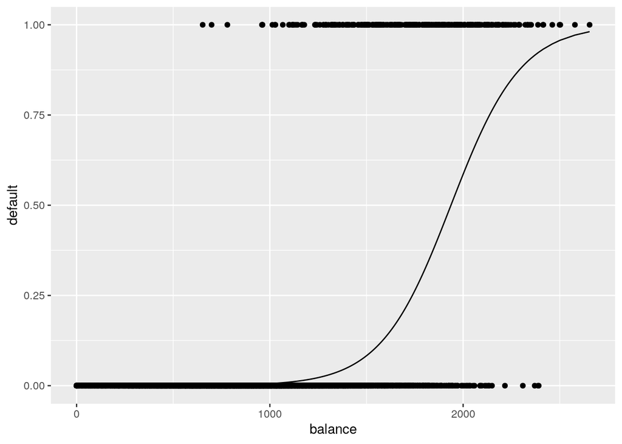

```r
m = 0.005499
b = -10.651331

# How to add "e"
dat_model_log = dat %>%
  mutate(default = as.integer(default)) %>%
  mutate(logistic_reg = (exp(m*balance + b))/(1 + (exp(m*balance + b))))

dat_model_log %>%
  ggplot(aes(x = balance)) +
  geom_point(aes(y = default)) +
  geom_line(aes(y = logistic_reg))
```

We still need a threshold!

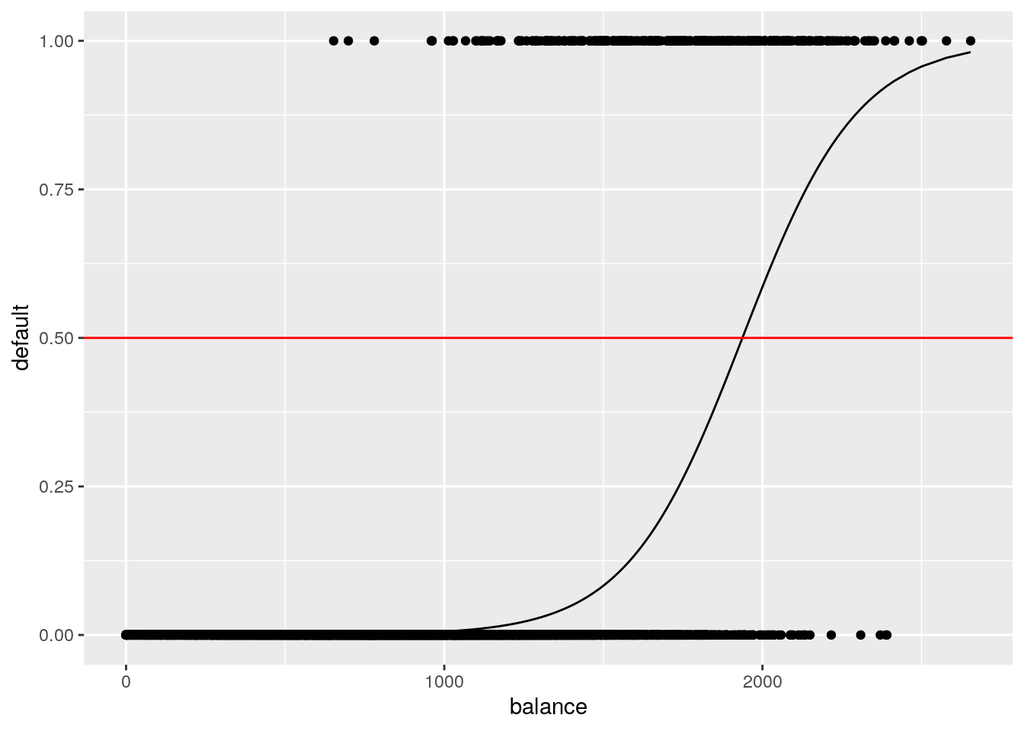

```r
probability_threshold = 0.5

dat_model_log %>%
  ggplot(aes(x = balance)) +
  geom_point(aes(y = default)) +
  geom_line(aes(y = logistic_reg)) +
  geom_hline(yintercept = probability_threshold, col = 'red')
```

Linear vs Logistic comparison

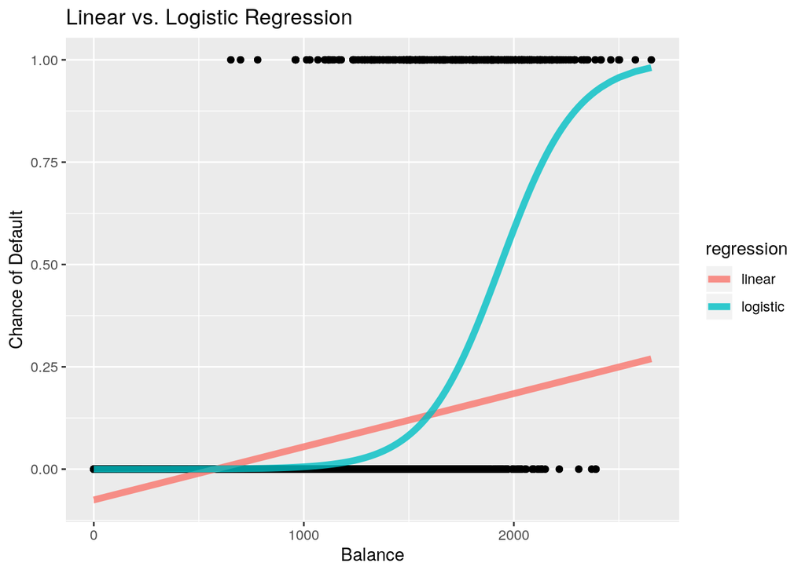

```r
dat_log_prep = dat_model_log %>%
  rename(predictions = logistic_reg) %>%
  select(balance, default, predictions) %>%
  mutate(regression = 'logistic')

dat_lin_prep = dat_model_lin %>%
  rename(predictions = default_predicted) %>%
  select(balance, default, predictions) %>%
  mutate(regression = 'linear')

dat_combo = bind_rows(dat_log_prep, dat_lin_prep)

dat_combo %>%
  ggplot(aes(x = balance)) +
  geom_point(aes(y = default)) +
  geom_line(aes(y = predictions, col = regression), size = 2, alpha = 0.8) +
  labs(title = 'Linear vs. Logistic Regression', y = 'Chance of Default', x = 'Balance')
```

```r
dat_model_log_preds = dat_model_log %>%
  mutate(default_prediciton = if_else(logistic_reg > probability_threshold, 1, 0)) %>%
  mutate(predicted_correct = if_else(default == default_prediciton, 1, 0))

dat_model_log_preds %>%
  select(balance, default, default_prediciton, predicted_correct) %>%
  summarize(predicted_correct = sum(predicted_correct)) %>%
  mutate(pct_correct = predicted_correct / total_number_of_rows)
```

```
## # A tibble: 1 x 2
##   predicted_correct pct_correct
##               <dbl>       <dbl>
## 1              9725       0.972
```

Rather than iterating through an showing a lot of these to minimize our error… we’ll use a package.

```r
model_log <- glm(default ~ balance,
                 family = 'binomial', data = dat)
summary(model_log)
```

```
##
## Call:
## glm(formula = default ~ balance, family = "binomial", data = dat)
##
## Deviance Residuals:
##     Min       1Q   Median       3Q      Max
## -2.2697  -0.1465  -0.0589  -0.0221   3.7589
##
## Coefficients:
##               Estimate Std. Error z value Pr(>|z|)
## (Intercept) -1.065e+01  3.612e-01  -29.49   <2e-16 ***
## balance      5.499e-03  2.204e-04   24.95   <2e-16 ***
## ---
## Signif. codes:  0 '***' 0.001 '**' 0.01 '*' 0.05 '.' 0.1 ' ' 1
##
## (Dispersion parameter for binomial family taken to be 1)
##
##     Null deviance: 2920.6  on 9999  degrees of freedom
## Residual deviance: 1596.5  on 9998  degrees of freedom
## AIC: 1600.5
##
## Number of Fisher Scoring iterations: 8
```

In order to look at results, we’ll use the fitted values rather than doing it all by hand. The `predict()` function is very handy as well as `prediction()`

```r
predictions = predict(model_log, type="response", data = dat)
head(predictions)
```

```
##            1            2            3            4            5            6
## 0.0013056797 0.0021125949 0.0085947405 0.0004344368 0.0017769574 0.0037041528
```

Viewing results, can utilize the `table()` function. It’s easy to change the probability threshold as well. How do we interpret the results?

```r
probability_threshold = 0.5
table(dat$default, predictions > probability_threshold)
```

```
##
##     FALSE TRUE
##   0  9625   42
##   1   233  100
```

The function `confusionMatrix` shows quite a bit more information but requires some changes in data types.

```r
probability_threshold = 0.9
preds = as.factor(predictions > probability_threshold)
actuals = as.factor(as.logical(dat$default))

confusionMatrix(preds, actuals)
```

```
## Confusion Matrix and Statistics
##
##           Reference
## Prediction FALSE TRUE
##      FALSE  9664  323
##      TRUE      3   10
##
##                Accuracy : 0.9674
##                  95% CI : (0.9637, 0.9708)
##     No Information Rate : 0.9667
##     P-Value [Acc > NIR] : 0.3614
##
##                   Kappa : 0.0554
##
##  Mcnemar's Test P-Value : <2e-16
##
##             Sensitivity : 0.99969
##             Specificity : 0.03003
##          Pos Pred Value : 0.96766
##          Neg Pred Value : 0.76923
##              Prevalence : 0.96670
##          Detection Rate : 0.96640
##    Detection Prevalence : 0.99870
##       Balanced Accuracy : 0.51486
##
##        'Positive' Class : FALSE
##
```

What do the above metrics mean??  
What is sensitivity? What is specificity? Why is specificity so low?

What about multiple variables?

```r
model_log = glm(default ~ student + balance, family = 'binomial', data = dat)
summary(model_log)
```

```
##
## Call:
## glm(formula = default ~ student + balance, family = "binomial",
##     data = dat)
##
## Deviance Residuals:
##     Min       1Q   Median       3Q      Max
## -2.4578  -0.1422  -0.0559  -0.0203   3.7435
##
## Coefficients:
##               Estimate Std. Error z value Pr(>|z|)
## (Intercept) -1.075e+01  3.692e-01 -29.116  < 2e-16 ***
## studentYes  -7.149e-01  1.475e-01  -4.846 1.26e-06 ***
## balance      5.738e-03  2.318e-04  24.750  < 2e-16 ***
## ---
## Signif. codes:  0 '***' 0.001 '**' 0.01 '*' 0.05 '.' 0.1 ' ' 1
##
## (Dispersion parameter for binomial family taken to be 1)
##
##     Null deviance: 2920.6  on 9999  degrees of freedom
## Residual deviance: 1571.7  on 9997  degrees of freedom
## AIC: 1577.7
##
## Number of Fisher Scoring iterations: 8
```

```r
probability_threshold = 0.5
predictions = predict(model_log, type = 'response', data = dat)
preds = as.factor(predictions > probability_threshold)
actuals = as.factor(as.logical(dat$default))

confusionMatrix(preds, actuals)
```

```
## Confusion Matrix and Statistics
##
##           Reference
## Prediction FALSE TRUE
##      FALSE  9628  228
##      TRUE     39  105
##
##                Accuracy : 0.9733
##                  95% CI : (0.9699, 0.9764)
##     No Information Rate : 0.9667
##     P-Value [Acc > NIR] : 8.229e-05
##
##                   Kappa : 0.4288
##
##  Mcnemar's Test P-Value : < 2.2e-16
##
##             Sensitivity : 0.9960
##             Specificity : 0.3153
##          Pos Pred Value : 0.9769
##          Neg Pred Value : 0.7292
##              Prevalence : 0.9667
##          Detection Rate : 0.9628
##    Detection Prevalence : 0.9856
##       Balanced Accuracy : 0.6556
##
##        'Positive' Class : FALSE
##
```

What’s wrong with our modeling process thus far?

We talked about test vs training data…

```r
reg_dat = dat %>%
  mutate(id = row_number())

set.seed(123)
dat_train = reg_dat %>%
  sample_frac(0.7)

dat_test = reg_dat %>%
  anti_join(dat_train, by = 'id') %>%
  select(-id)

dat_train = dat_train %>%
  select(-id)
```

```r
head(dat_train)
```

```
## # A tibble: 6 x 4
##   default student balance income
##     <dbl> <fct>     <dbl>  <dbl>
## 1       0 No        1236. 48800.
## 2       0 No           0  33933.
## 3       0 No        1171. 49833.
## 4       0 No         221. 31764.
## 5       0 Yes       1183. 17288.
## 6       0 No         556. 40838.
```

```r
head(dat_test)
```

```
## # A tibble: 6 x 4
##   default student balance income
##     <dbl> <fct>     <dbl>  <dbl>
## 1       0 Yes        817. 12106.
## 2       0 No         529. 35704.
## 3       0 No        1161. 37469.
## 4       0 No         607. 44995.
## 5       0 No        1113. 23810.
## 6       0 No         286. 45042.
```

```r
model_log = glm(default ~ ., family = 'binomial', data = dat_train)
summary(model_log)
```

```
##
## Call:
## glm(formula = default ~ ., family = "binomial", data = dat_train)
##
## Deviance Residuals:
##     Min       1Q   Median       3Q      Max
## -2.5518  -0.1390  -0.0530  -0.0189   3.7648
##
## Coefficients:
##               Estimate Std. Error z value Pr(>|z|)
## (Intercept) -1.135e+01  5.904e-01 -19.225   <2e-16 ***
## studentYes  -5.123e-01  2.826e-01  -1.813   0.0699 .
## balance      5.904e-03  2.807e-04  21.031   <2e-16 ***
## income       8.935e-06  9.619e-06   0.929   0.3529
## ---
## Signif. codes:  0 '***' 0.001 '**' 0.01 '*' 0.05 '.' 0.1 ' ' 1
##
## (Dispersion parameter for binomial family taken to be 1)
##
##     Null deviance: 2130.6  on 6999  degrees of freedom
## Residual deviance: 1108.2  on 6996  degrees of freedom
## AIC: 1116.2
##
## Number of Fisher Scoring iterations: 8
```

```r
probability_threshold = 0.5

predictions = predict(model_log, newdata = dat_test, type = 'response')
preds = as.factor(predictions > probability_threshold)
actuals = as.factor(as.logical(dat_test$default))

confusionMatrix(preds, actuals)
```

```
## Confusion Matrix and Statistics
##
##           Reference
## Prediction FALSE TRUE
##      FALSE  2898   65
##      TRUE     15   22
##
##                Accuracy : 0.9733
##                  95% CI : (0.9669, 0.9788)
##     No Information Rate : 0.971
##     P-Value [Acc > NIR] : 0.2424
##
##                   Kappa : 0.3435
##
##  Mcnemar's Test P-Value : 4.293e-08
##
##             Sensitivity : 0.9949
##             Specificity : 0.2529
##          Pos Pred Value : 0.9781
##          Neg Pred Value : 0.5946
##              Prevalence : 0.9710
##          Detection Rate : 0.9660
##    Detection Prevalence : 0.9877
##       Balanced Accuracy : 0.6239
##
##        'Positive' Class : FALSE
##
```

Due to the massive imbalance in our training data, the base rate fallacy hasn’t been accounted for which makes it hard to predict default with as much accuracy.

How can we fix the issue of class imbalance?

```r
dat_train = dat_train %>% mutate(default = as.factor(default))
dat_train %>%
  group_by(default) %>%
  count()
```

```
## # A tibble: 2 x 2
## # Groups:   default [2]
##   default     n
##   <fct>   <int>
## 1 0        6754
## 2 1         246
```

```r
dat_train_up = upSample(dat_train %>% select(-default), dat_train$default)
dat_train_up %>%
  group_by(Class) %>%
  count()
```

```
## # A tibble: 2 x 2
## # Groups:   Class [2]
##   Class     n
##   <fct> <int>
## 1 0      6754
## 2 1      6754
```

```r
model_log = glm(Class ~ ., family = 'binomial', data = dat_train_up)
summary(model_log)
```

```
##
## Call:
## glm(formula = Class ~ ., family = "binomial", data = dat_train_up)
##
## Deviance Residuals:
##     Min       1Q   Median       3Q      Max
## -3.6189  -0.2879   0.0073   0.3474   2.7776
##
## Coefficients:
##               Estimate Std. Error z value Pr(>|z|)
## (Intercept) -8.116e+00  2.042e-01 -39.749  < 2e-16 ***
## studentYes  -4.597e-01  1.007e-01  -4.566 4.97e-06 ***
## balance      5.952e-03  1.032e-04  57.698  < 2e-16 ***
## income       8.594e-06  3.516e-06   2.444   0.0145 *
## ---
## Signif. codes:  0 '***' 0.001 '**' 0.01 '*' 0.05 '.' 0.1 ' ' 1
##
## (Dispersion parameter for binomial family taken to be 1)
##
##     Null deviance: 18726.1  on 13507  degrees of freedom
## Residual deviance:  7349.8  on 13504  degrees of freedom
## AIC: 7357.8
##
## Number of Fisher Scoring iterations: 6
```

Should we upsample the test data as well?

How do you like this model in comparison?

```r
probability_threshold = 0.5

predictions = predict(model_log, newdata = dat_test, type = 'response')
preds = as.factor(predictions > probability_threshold)
actuals = as.factor(as.logical(dat_test$default))

confusionMatrix(preds, actuals)
```

```
## Confusion Matrix and Statistics
##
##           Reference
## Prediction FALSE TRUE
##      FALSE  2551   14
##      TRUE    362   73
##
##                Accuracy : 0.8747
##                  95% CI : (0.8623, 0.8863)
##     No Information Rate : 0.971
##     P-Value [Acc > NIR] : 1
##
##                   Kappa : 0.2431
##
##  Mcnemar's Test P-Value : <2e-16
##
##             Sensitivity : 0.8757
##             Specificity : 0.8391
##          Pos Pred Value : 0.9945
##          Neg Pred Value : 0.1678
##              Prevalence : 0.9710
##          Detection Rate : 0.8503
##    Detection Prevalence : 0.8550
##       Balanced Accuracy : 0.8574
##
##        'Positive' Class : FALSE
##
```